# QMEE HPC coursework feedback

13-03-2023

### Setup

```
## This document provides marks and feedback on ANQI WANG's HPC coursework submission.
```

### Section 1

**Question 1**

```
## Correct answer
```

```
## Marks awarded: 2/2
```

**Question 2**

```
## Correct answer
```

```
## Marks awarded: 1/1
```

**Question 3**

```
## Correct answer
```

```
## Marks awarded: 1/1
```

**Question 4**

```
## Correct answer
```

```
## Marks awarded: 2/2
```

**Question 5**

```
## Correct answer
```

```
## Marks awarded: 2/2
```

**Question 6**

This is not right - the vector `generation_nums` you create has got two entries, and I think your intention was that this be one number which is equal to the number of time steps in a generation. But then in your for loop, you cycle `step` through this vector. Since there are only two values in the vector, you only carry out `neutral_step` twice rather than for an entire generation.

It would have been helpful for you to check each step of this outside of the function before wrapping it up in a function and assuming it works as intended.

```
## Marks awarded: 0/2
```

**Question 7**

There is a mistake here where you record the initial species richness twice and do not record the final species richness at all. Have a look at the order of the commands in the for loop.

```
## Marks awarded: 1/2
```

**Question 8**

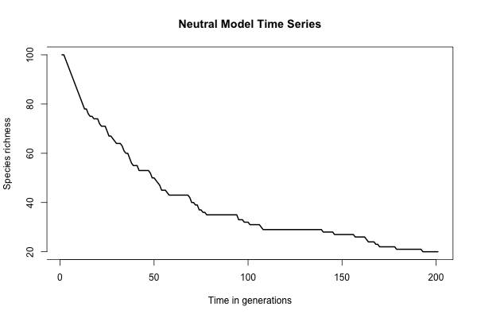

*What state will the system always converge to if you wait long enough? Why is this?*

The system always converge to a point where the species richness is equal to 1. Because there is no new species add in, therefore the species richness can’t increase, but the species can be lost through extinction. The extinct species cannot re-enter the community, therefore, due to the stochasticity of the system, the community will eventually randomly lose all species but one.

*Feedback*

Perfect answer!

```
## Marks awarded: 3/3
```

**Question 9**

```
## Correct answer
```

```
## Marks awarded: 3/3
```

**Question 10**

Good! Why is it that you didn’t repeat any of the same errors from `neutral_generation` here?

```
## Correct answer
```

```
## Marks awarded: 1/1
```

**Question 11**

I have the same query here. If you are comparing notes with others, make sure you really think about the differences between others’ approaches and your own approach and determine for yourself what the correct approach is. If you had done this, I think it is likely you would have been able to notice and correct the errors in the earlier functions for yourself and learn something in doing so.

```
## Correct answer
```

```
## Marks awarded: 1/1
```

**Question 12**

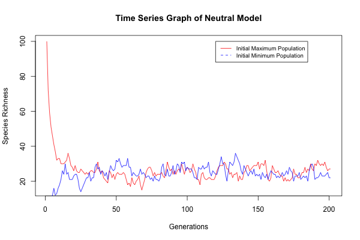

*Explain what you found from this plot about the effect of initial conditions. Why does the neutral model simulation give you those particular results?*

When a community is simulated by the neutral model with the same rate of speciation, there is likely to have a dynamic equilibrium. There is no obvious impact of the initial states of richness, because the chances of extinction and speciation are the same in both populations. However, the model with speciations prevents the mono-dominance from persisting as new species can occur in both scenarios. Regardless of initial values, evaluate the speciation rate and numbers of individuals, and they would converge to a dynamic equilibrium with similar pattern.

*Feedback*

Good answer and explanation, although a little roundabout! Watch out for grammar and readability. The only problem is that the figure legend is a little misleading; what does “initial minimum population” mean? That the population size is minimum? What is the accurate statement here to describe this initial condition? (Use the word “community” rather than “population”, and make sure you include the key word differentiating the two conditions).

```
## Marks awarded: 3/4
```

**Question 13**

```
## Correct answer
```

```
## Marks awarded: 3/3
```

**Question 14**

```
## Correct answer
```

```
## Marks awarded: 3/3
```

**Question 15**

```
## Correct answer
```

```
## Marks awarded: 2/2
```

**Question 16**

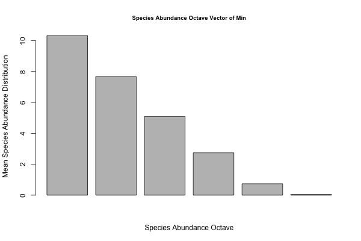

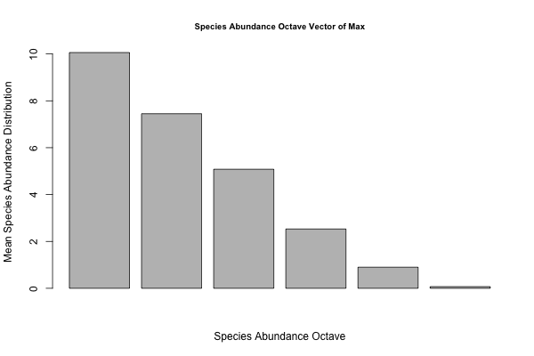

*Does the initial condition of the system matter? Why is this?”*

The initial richness of the system does not affect the final results. As the speciation rate is equal to all the simulated community in the neutral model, the species abundance follows a Poisson distribution shape. Therefore, no matter the initial richness is, the system tends to have the same trends and get a dynamic equilibrium.

*Feedback*

Very nice graphs except that the titles do not helpfully explain what the different initial conditions were.

Your answer has some good thoughts in, but does not effectively explain why the initial conditions do not affect the observed octaves. Also, be careful to be accurate - it is not true that the neutral model octaves follow a Poisson distribution (although they may look similar).

```
## Marks awarded: 2/4
```

**Question 17**

Great!

```
## Marks awarded: 6/6
```

**Question 18**

Perfect!

```
## Marks awarded: 6/6
```

**Question 19**

Fantastic.

```
## Marks awarded: 10/10
```

**Question 20**

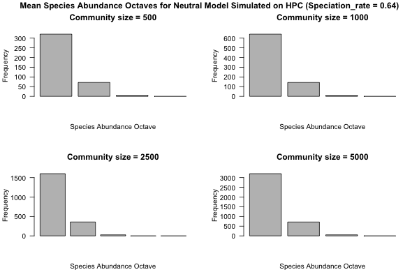

Comparing your results with results from a coalescence simulation (rounded to nearest whole number).

```
## Size 500:
## Your results:
```

```
## 320 71 5 0
```

```
## My results:
```

```
## 320 72 5 0
```

```
##
## Size 1000:
## Your results:
```

```
## 640 143 10 0
```

```
## My results:
```

```
## 641 143 10 0
```

```
##
## Size 2500:
## Your results:
```

```
## 1603 358 26 0 0
```

```
## My results:
```

```
## 1601 356 26 0
```

```
##
## Size 5000:
## Your results:
```

```
## 3204 714 52 0
```

```
## My results:
```

```
## 3196 717 52 0
```

Excellent! Your graph and code are fantastic.

```
## Marks awarded: 10/10
```

### Section 2

**Question 21**

```
## Correct answer
```

```
## Marks awarded: 1/1
```

**Question 22**

```
## Correct answer
```

```
## Marks awarded: 2/2
```

**Question 23**

```
## Correct answer
```

```
## Marks awarded: 1/1
```

**Question 24**

```
## Correct answer
```

```
## Marks awarded: 3/3
```

**Question 25**

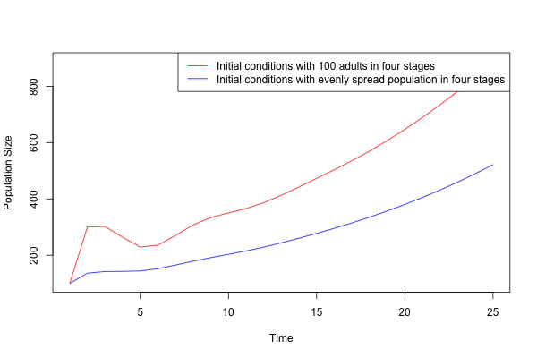

*How does the initial distribution of the population in different life stages affect the initial and eventual population growth?*

The initial distribution of the population in different life stages can affect the initial and eventual population growth. For example, a population with a large proportion of individuals in the reproductive age range is more likely to have a higher growth rate than a population with a smaller proportion of individuals in this age range.

*Feedback*

Good - but why? Try to be more explicit. Also, this is a deterministic model, so whether things are more or less “likely” is not important. We know exactly what is going to happen!

The graph and code are great.

```
## Marks awarded: 3/4
```

**Question 26**

```
## Correct answer
```

```
## Marks awarded: 3/3
```

**Question 27**

```
## Correct answer
```

```
## Marks awarded: 4/4
```

**Question 28**

```
## Correct answer
```

```
## Marks awarded: 2/2
```

**Question 29**

```
## Correct answer
```

```
## Marks awarded: 1/1
```

**Question 30**

```
## Correct answer
```

```
## Marks awarded: 2/2
```

**Question 31**

```
## Correct answer
```

```
## Marks awarded: 2/2
```

**Question 32**

```
## Correct answer
```

```
## Marks awarded: 5/5
```

**Question 33**

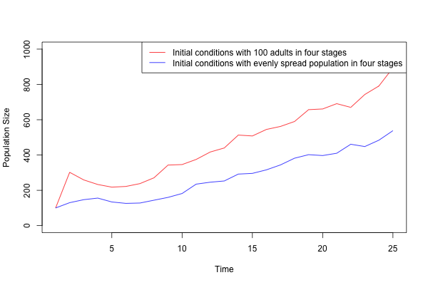

*How does the smoothness of the earlier deterministic simulations compare with these stochastic simulations? Why?*

The earlier deterministic simulations were smooth, while the stochastic simulations are more jagged. This is because the deterministic simulations assumed a fixed number of clutches each time step, while the stochastic simulations randomly selected the number of clutches from a given distribution.

*Feedback*

Very good understanding! Your explanation is a little inaccurate - for example, the number of clutches each time step is not fixed in the deterministic model - but it is *determined* rather than random. Also, note that survival and maturation are also drawn randomly from a distribution as well as recruitment.

```
## Marks awarded: 2/3
```

**Question 34**

Great!

```
## Marks awarded: 6/6
```

**Question 35**

Perfect!

```
## Marks awarded: 10/10
```

**Question 36**

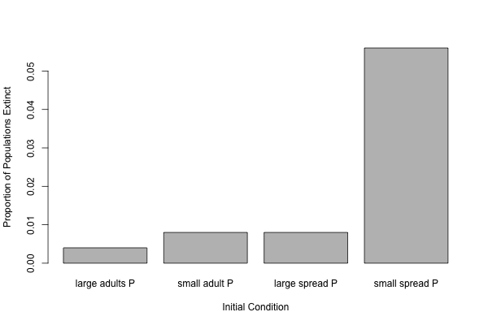

*Which population was most likely to go extinct? Why do you think this is?*

*Feedback*

```
## Marks awarded: 6/8
```

**Question 37**

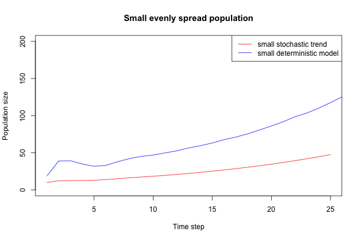

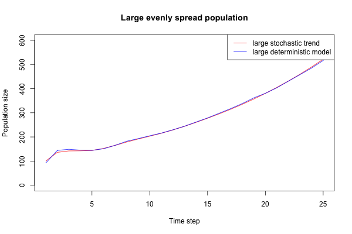

*When is it appropriate or not appropriate to approximate the ‘average’ behaviour of this stochastic system with a deterministic model?*

Depends on the population size, the large evenly spread population shows a more appropriate simulation. As in the large evenly spread population, the expected and deterministic trend lines nearly lapped. However, in the small evenly spread population, there are differences but still follows at the similar increasing trends. This might because of the recruitment and clutch probability used in this deterministic is the most idea expected, although took the randomly sampling into count, there is still the ‘idea’ condition. Therefore, in a small evenly spread population, shows obvious.

*Feedback*

It was nice that you showed the initial portion of population growth as this shows the most obvious differences; I think this may have been an accident from copying over the same plotting code as earlier in the worksheet - but it made it easier to spot the differences so that’s good!

Your answer is quite hard to follow because it is not written in good full sentences (for example, what does the last sentence mean?) - but I think you have noticed the pattern. However, you have not effectively explained under what circumstances the deterministic simulation is a good predictor of the average behaviour - and one key factor you have not considered is probability of extinction in the stochastic model.

```
## Marks awarded: 7/10
```

### Challenge questions

**Challenge Question A**

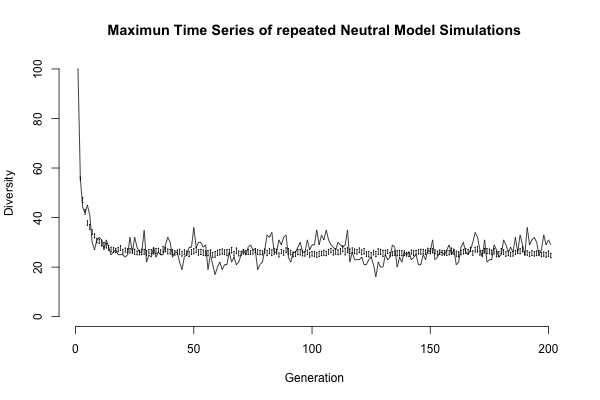

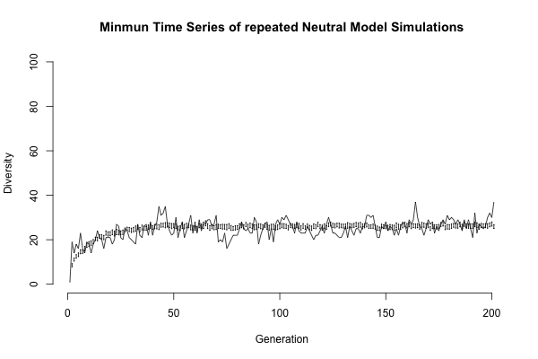

Fantastic! The only coding issue is that you used the value of 0.972 as `p` in the input to `qnorm`, which is the equivalent to doing a one-tailed rather than two-tailed test. Can you think of how to modify this?

Overall the graphs looks good. However, your graph titles are not very helpful, and it is not clear what the different lines are that have been plotted; you should make it clear which is the mean line/confidence intervals, and what the other line means. Finally, the mean species richness value is not actually clear from the plot (it is covered up by the confidence interval bars and the simulation line) - and this was the main point of the question.

```
## Marks awarded: 7/10
```

**Challenge Question B**

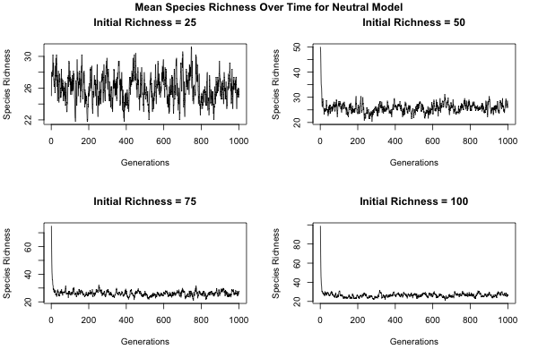

You’re most of the way there with just a few issues! Firstly, your `initialise_community` function is not doing quite what it says it does (try it on its own and see if it works). This could have been made much simpler! Secondly, five simulations is not really enough - the question asks for *many*. You can see from how un-smooth the lines are that we really need to average over quite a few more simulations! The graph is fantastic!

```
## Marks awarded: 7/10
```

**Challenge Question C**

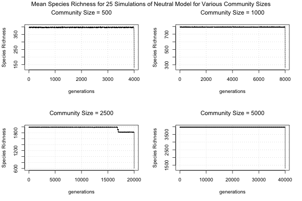

It looks like something strange happens at the end of the simulations - but I will ignore that as it may be a cluster issue.

This question is all about burn-in period. You should have chosen a different scale for the x-axis in order to answer this question; the idea was that these graphs would inform you how long the simulation needs to be run for in order to get to dynamic equilibrium. Can you think of a sensible value of x (generation) to limit the graph to such that we could observe the system approaching equilibrium?

```
## Marks awarded: 8/10
```

**Challenge Question D**

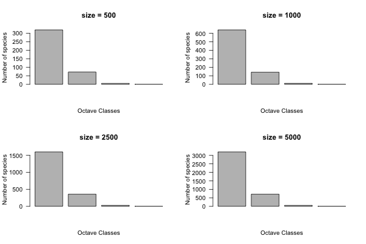

*How many CPU hours were used on the coalescence simulation and how many on the cluster to do an equivalent set of simulations? Why were the coalescence simulations so much faster?*

*Feedback*

Excellent code and answer, and the graphs are nice! Just a few issues. Firstly, you were asked to produce a graph to *compare* the coalescence model and your cluster simulation - but your graph only shows the coalescence calculations. Secondly, you have only generated 200 data points using the coalescence model - which is not equivalent to the cluster runs which generated many more data points than this. On the graphs, I would have liked the octave classes to be labelled.

```
## Marks awarded: 8/10
```

**Challenge Question E**

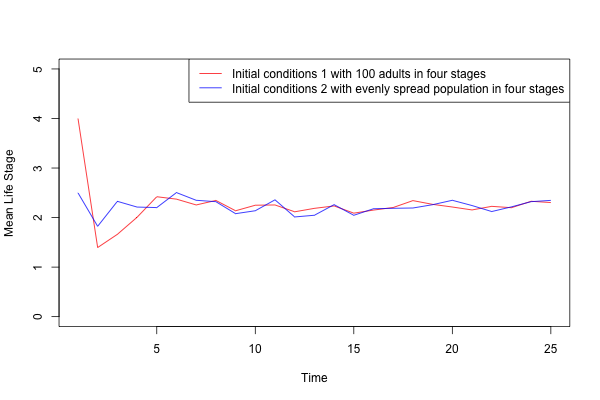

*How do the two simulations differ in terms of the initial behaviour of the graph of mean life stage against time? Why?*

*Feedback*

```
## Marks awarded: 7/10
```

**Challenge Question F**

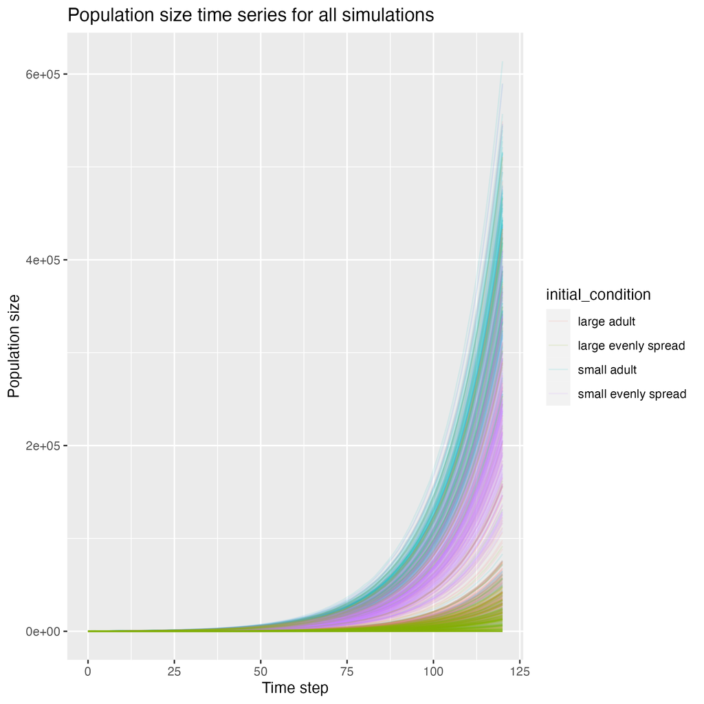

Lovely! The only mistake is that you read in the data wrong from your cluster output files - look back to the demographic_cluster.R file you wrote and check your file numbers. You can spot this quickly because you wouldn’t expect the smaller initial population sizes to result in a larger eventual population (the turquoise colour).

The graph is nice, but the legend is quite hard to read. I think you need to investigate the legend options in ggplot2 and find out how to make the legend example lines thicker and more solid.

```
## Marks awarded: 8/10
```

### Quality of writing, graphs, and code

**Quality of free text answers**

It was hard to follow quite a few of the free text answers, and there were many grammatical mistakes and sometimes spelling mistakes.

```
## Marks awarded: 4/10
```

**Quality of graphical outputs**

These were generally good but pay closer attention to detail and watch out for spelling mistakes.

```
## Marks awarded: 7/10
```

**Quality of code**

Code was great but I would have liked more straightforward code or explanation (in the form of comments) when your code was not straightforward. There were some errors and inelegant workarounds in some of your functions.

```
## Marks awarded: 8/10
```

### Summary

```
## Summary of marks for ANQI WANG:
```

```
## Total marks for section 1: 62/68 (91%)
```

[output not shown]

```
##                               Section MarksAwarded MarksAvailable Percentage
## 1      Main questions (60% weighting)          122            135         90
## 2      Quality of text (8% weighting)            4             10         40
## 3   Quality of graphs (10% weighting)            7             10         70
## 4      Quality of code (8% weighting)            8             10         80
## 5 Challenge questions (14% weighting)           45             60         75
```

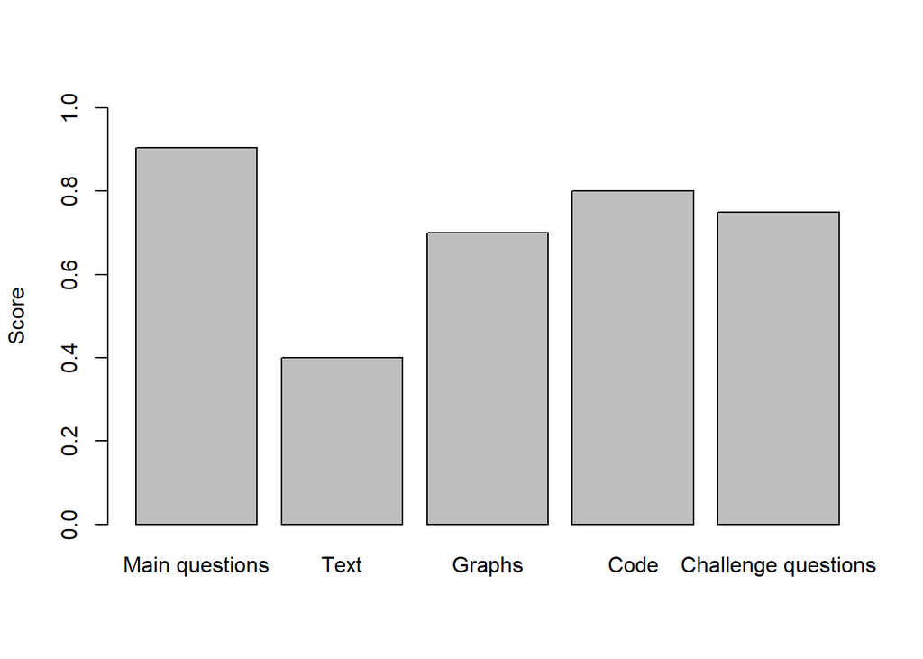

```
## Overall mark for HPC coursework: 81.32%
```

You made a very successful attempt at most questions! Work on understanding the questions on a deeper level and answering the questions really clearly so that your thinking is obvious to the reader. Also watch out for your attention to detail and ensure all parts of your code work before packaging it into something more complex. Well done Anqi!

**—– End of document —–**